# Time Series: A First Course with Bootstrap Starter

# Lesson 3-5: Seasonality

- Regular patterns of a periodic nature are called *seasonality*.
- The same notion as a *cycle*, but is associated with the calendar.
- We may wish to estimate and remove seasonality in order to see other patterns.

## Example 3.5.1. Mauna Loa Growth Rate

- We consider the Mauna Loa CO2 time series.

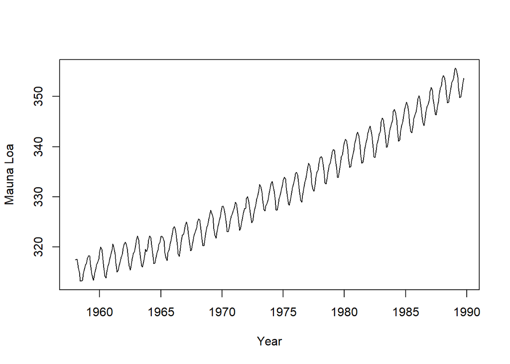

```r
mau <- read.table("mauna.dat",header=TRUE,sep="")
mau <- ts(mau,start=1958,frequency=12)
plot(mau,xlab="Year",ylab="Mauna Loa")
```

- We can difference the series to eliminate the trend.
- A pronounced seasonal pattern is apparent; but it is not completely periodic.

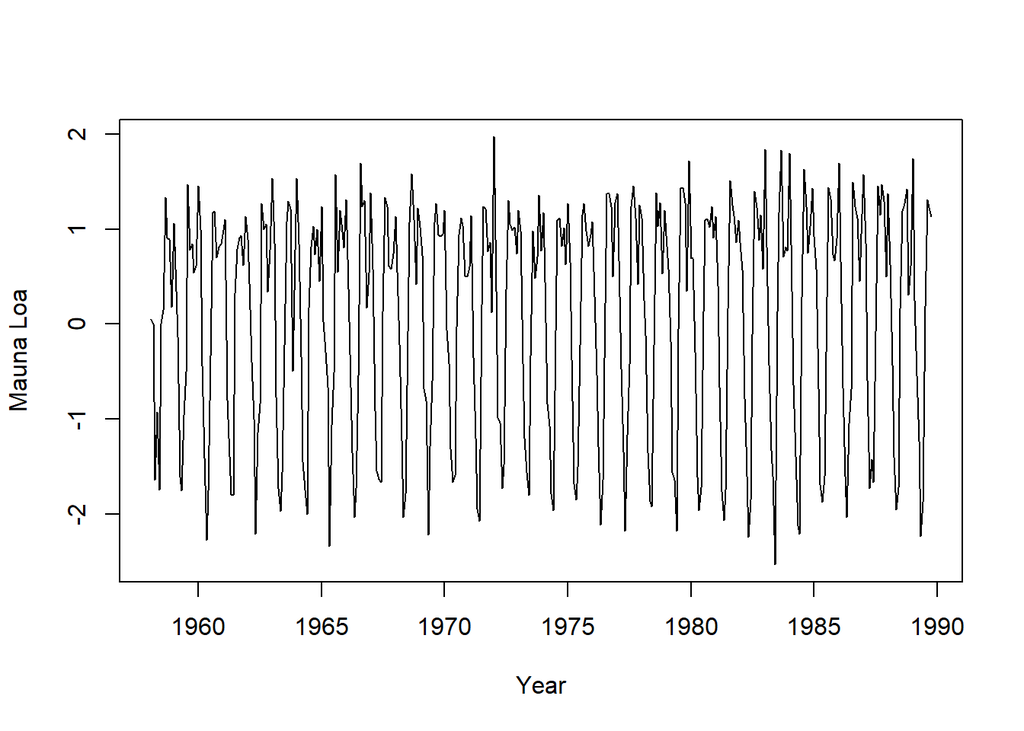

```r
mau.diff <- diff(mau)
plot(mau.diff,xlab="Year",ylab="Mauna Loa")
```

## Seasonal Regression

- An exactly periodic effect would be $X_t = X_{t-s}$ for seasonal period $s$ (e.g., $s=12$ for monthly time series), and any $t$.
- If this were true, we could use dummy regressors. Usually this works poorly; if the series were periodic, then the filter $1 - B^s$ would annihilate it.
- Example of Mauna Loa; seasonal differencing of the growth rate leaves a non-zero time series.

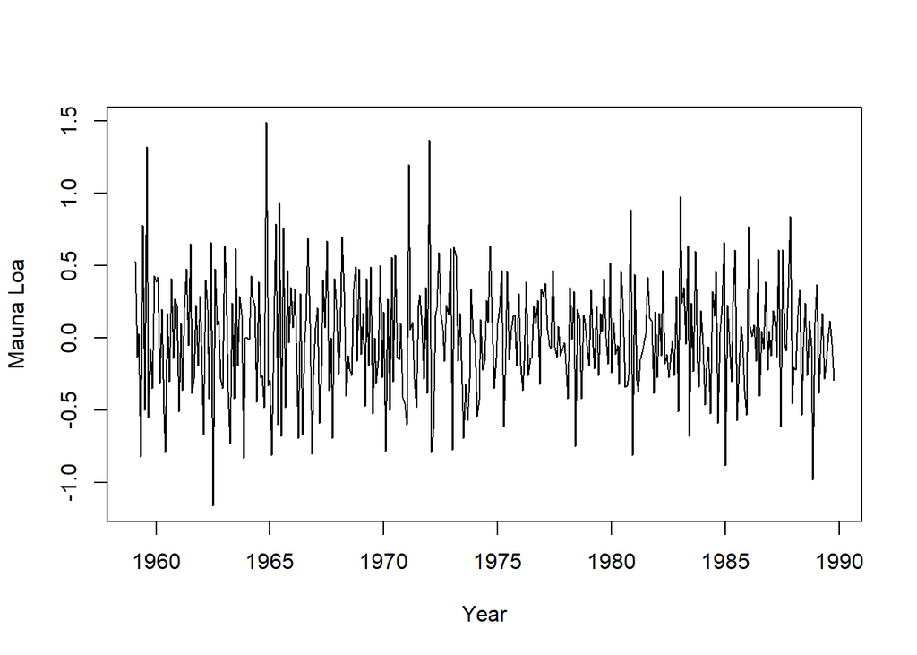

```r
mau.diffs <- diff(mau.diff,lag=12)
plot(mau.diffs,xlab="Year",ylab="Mauna Loa")
```

## Seasonal Moving Average

- A better way is to estimate seasonality using a *seasonal moving average*. This is a moving average filter where only coefficients with indices that are a multiple of $s$ are non-zero.
- This means
  $$\Psi (B) = \sum_{k = -ms}^{ms} \psi_k B^k
  = \sum_{j=-m}^m \psi_{js} B^{js}$$
  is a seasonal moving average, because $\psi_k = 0$ unless $k = js$ for some integer $j$.

## Example 3.5.8. Seasonal Moving Average for Motor Retail Sales

- We apply a seasonal moving average to the growth rate of the Motor Retail Sales data, with $m=3$.
- We plot the growth rate series, the estimated seasonality, and the residual after subtracting off the seasonal component.

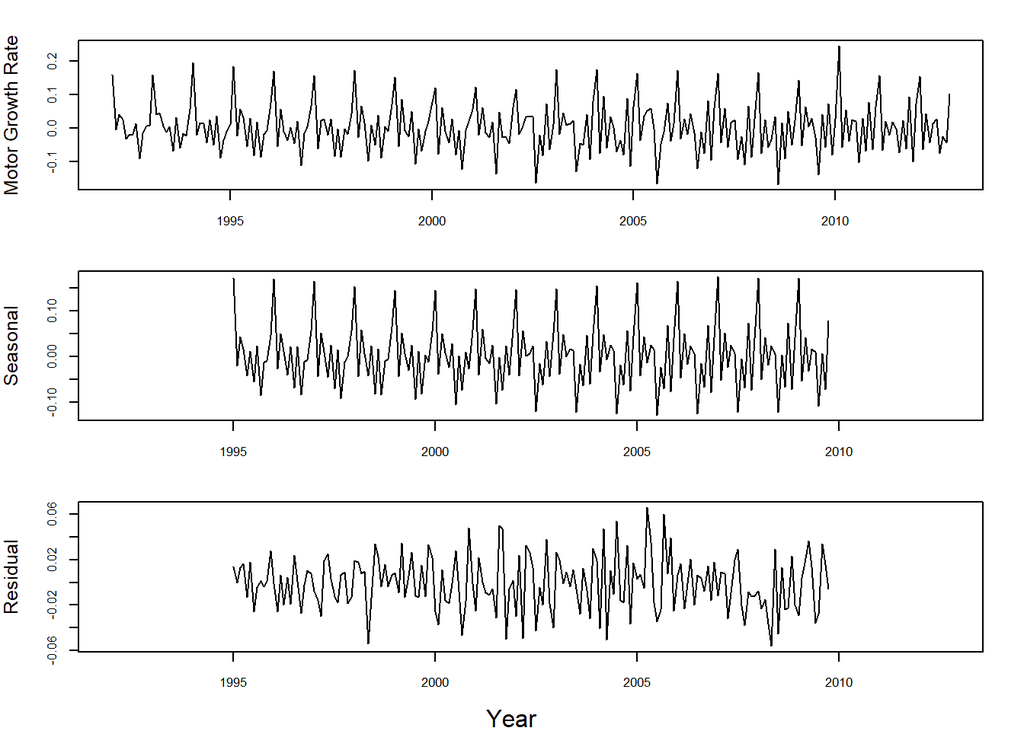

```r
Ret441 <- read.table("retail441.b1",header=TRUE,skip=2)[,2]
Ret441 <- ts(Ret441,start = 1992,frequency=12)
ret.diff <- diff(log(Ret441))

pseas <- 3
period <- 12
seas.smoother <- c(1,rep(0,period-1))
seas.smoother <- c(rep(seas.smoother,pseas),rep(seas.smoother,pseas),1)/(2*pseas+1)
seas.smooth <- stats::filter(ret.diff,seas.smoother,method="convolution")
seas.resid <- ret.diff - seas.smooth

par(oma=c(2,0,0,0),mar=c(2,4,2,2)+0.1,mfrow=c(3,1),cex.lab=1.2)
plot(ret.diff,ylab="Motor Growth Rate",xlab="",yaxt="n",xaxt="n")
axis(1,cex.axis=.8)
axis(2,cex.axis=.8)
plot(ts(seas.smooth,start=1992,frequency=12),xlab="",ylab="Seasonal",yaxt="n",xaxt="n")
axis(1,cex.axis=.8)
axis(2,cex.axis=.8)
plot(ts(seas.resid,start=1992,frequency=12),xlab="",ylab="Residual",yaxt="n",xaxt="n")
axis(1,cex.axis=.8)
axis(2,cex.axis=.8)
mtext(text="Year",side=1,line=1,outer=TRUE)
```

## Remark 3.5.9. Seasonal Adjustment

- Removal of seasonality is called *seasonal adjustment*.
- The *seasonal aggregation* filter is defined as
  $$U(B) = 1 + B + B^2 + \ldots + B^{s-1}.$$
  It annihilates any periodic pattern, and is a basic example of a seasonal adjustment filter.

## Example 3.5.10. Seasonal Adjustment of Mauna Loa Growth Rate

- We apply the seasonal aggregation filter to the growth rate of the Mauna Loa CO2 time series.
- This uses a trick: applying $U(B)$ and $1-B$ together amounts to applying $1-B^s$, because
  $$U(B) (1 - B) = 1- B^s.$$

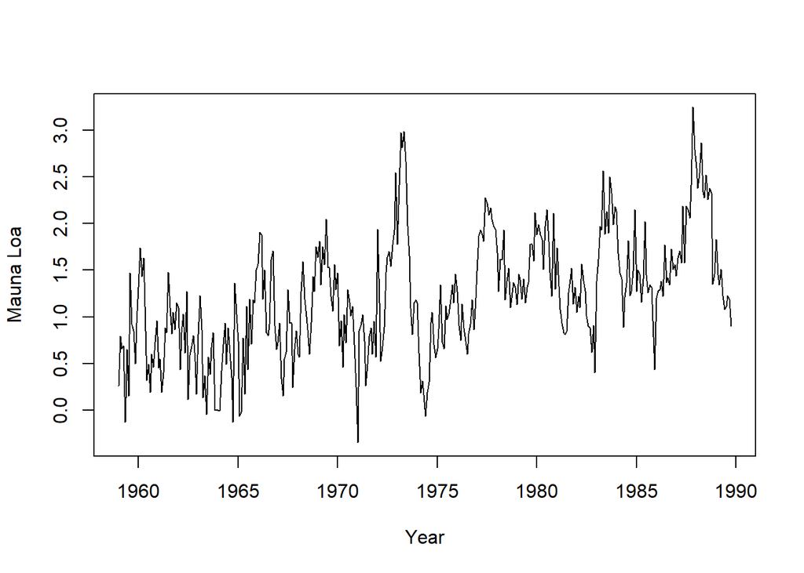

```r
seas.elim <- diff(mau,lag=12)
plot(seas.elim,xlab="Year",ylab="Mauna Loa")
```